# Cleaning Data & The Skies II

[figure not shown]

[Image source - Smog hangs over Los Angeles, California](https://phys.org/news/2018-04-california-worst-air-pollution.html) ("cover_image.jpg")

#### This project is an extension of the first version (*Cleaning Data & The Skies I*), the difference being that section four (**Analysis IV**) is analyzed differently. More specifically, hypothesis testing was used to analyze the fourth point of interest. The original version of the project did not use such methods.

#### This project was completed in September, 2025.

## 📖 Background

Your are a data analyst working at an environmental company. You are tasked with evaluating ozone pollution across various regions.

You’ve obtained data from the U.S. Environmental Protection Agency (EPA) containing daily ozone measurements at monitoring stations across California. However, like many real-world datasets, it’s far from clean; there are missing values, inconsistent formats, potential duplicates, and outliers.

Before you can provide meaningful insights, the data must be cleaned and validated. Only then can it be analyzed to uncover trends, identify high-risk regions, and assess where policy interventions are most urgently needed.

## 💾 The Data

The data is a modified dataset from the U.S. Environmental Protection Agency ([EPA](https://www.epa.gov/outdoor-air-quality-data/download-daily-data)). The `ozone.csv` file contains daily air quality summary statistics monitored for the state of California for 2024. Each row contains the date and the air quality metrics per collection method and site.

[output not shown]

# Objectives

Create a report that covers the following: 1) Your EDA and data cleaning process. 2) How does daily maximum 8-hour ozone concentration vary over time and regions? 3) Are there any areas that consistently show high ozone concentrations? Do different methods report different ozone levels? 4) Consider if urban activity (weekend vs. weekday) has any effect on ozone levels across different days.

*Bonus*: plot a geospatial heatmap showing any high ozone concentrations.

# Summary of Findings & Recommendations

This project analyzed environmental data pertaining to the state of California during 2024. More specifically, the air quality was evaluated across a variety of factors to assess how it evolved over the year & across different parts of the state, what areas saw particularly high concentrations of ozone, how air quality readings differed based on the collection method utilized, & how it may have been impacted according to the day of the week. Various tools & techniques were used to help evaluate such trends & risk levels including data visualizations, statistical analyses, aggregate analyses, & hypothesis testing.

There were four main objectives in the whole project; **however, this specific file only included analyses for the fourth**. For more information regarding details of analyses & findings for each objective, they can be found at the end of each section.

- **NOTE:** The steps from **Analysis I** in the first file for this project (*Cleaning Data & the Skies I*) were also included in this file in order to preprocess the original dataset & have access to the same cleaned version. This work accounts for the majority of this file. To review summaries of the work done in the first three sections of analyses, refer to the first version of this project (*Cleaning Data & the Skies I*).

### Analysis IV - Day of Week & Ozone Levels

It was theorized that ozone levels may differ between weekdays & weekends because different kinds & quantities of urban activity usually take place during the week & on the weekend. For example, a large chunk of the general population has to commute to & from their workplace between Monday & Friday, whereas they are more likely to stay home on the weekend. Through the usage of transportation, gas & diesel vehicles emit chemicals & gases that can form into ozone in certain conditions, specifically when interacting with sunlight & high temperatures. This reasoning is behind the inquiry as to whether urban activity might relate to ozone levels.

In *Cleaning Data & the Skies I*, straightforward statistical analyses were conducted the results of which proved inconclusive. More specifically, ozone levels were analyzed across weekdays vs weekends, different days of the week, on a monthly basis, & across a specific county. Ultimately, they failed to find any meaningful differences in the ozone levels.  
This file, *Cleaning Data & the Skies II*, extends these analyses into more powerful statistical techniques, specifically hypothesis tests.

Given the nature of the data, parametric, two-tailed t-tests were used to evaluate whether average ozone levels were different between weekdays & weekends in California in 2024. First, these averages were assessed across the entire dataset. Using a significance level of five percent, the hypothesis test yielded a p-value of about 0.26%. As such, the null hypothesis was rejected in favor of the alternative. More specifically, the average ozone level observed during the week was about 0.00043 ppm higher than on the weekends. The p-value indicates that this difference is statistically significant.

Secondly, average ozone levels across weekdays & weekends were evaluated specifically for the county of Los Angeles. Using a significance level of five percent, the hypothesis test yielded a p-value of about 4.06%. As such, the null hypothesis was rejected in favor of the alternative. More specifically, the average ozone level observed on the weekends in Los Angeles county was about 0.001143 ppm higher than during the week. The p-value indicates that this difference is statistically significant.

**Recommendations**: If it is assumed that urban activity is the main catalyst regarding differences in ozone levels between weekends & weekdays in this dataset, then these results indicate that urban activity did have a meaningful effect on ozone levels observed in California in 2024 across different days of the week. With this in mind, urban activity generally resulted in ozone levels being slightly higher during the week than on weekends during 2024 in California. Conversely, for the county of Los Angeles, urban activity resulted in ozone levels being slightly lower during the week than on weekends during 2024.

One way to interpret these findings could include extending the logic described previously. If urban activity is related to ozone levels, it is likely to be in a positive way--more urban activity (e.g. vehicular transportation) leads to higher ozone levels. Assuming this is the case, then it can be said that in California overall during 2024, urban activity was slightly greater during the week than on the weekends. Furthermore, this could be a sign that people were slightly more active during the week than on weekends. For Los Angeles county in particular, the opposite was true--urban activity was slightly greater on weekends than during the week.

These findings could be used in a variety of ways depending on how urban activity is defined & interpreted. In continuing with the transportation topic, these findings could indicate that vehicular usage was slightly more common during the week across California in 2024, whereas for Los Angeles county, it was slightly more common on the weekends. As an example, such insights could be used when assessing traffic patterns & associated problems such as congestion, traffic jams, potential for vehicular accidents, & delays from construction projects. For instance, it might affect less people in Los Angeles county to do more construction on roadways on weekdays than on weekends. Alternatively, emergency services could implement these findings to help prepare for certain days & times in which accidents may be more likely to happen as a result of increased urban activity.  
On another note, if the state wanted to impose taxes on more environmentally-expensive vehicles (those that release more chemicals & gases into the air like diesel-engined cars), taxes could be made slightly higher on weekdays throughout the state because urban activity (peoples' usage of vehicles) is slightly greater during the week than on weekends.  
Such examples can provide an illustration as to how the data & insights obtained in this section could be utilized in decision-making.

Further analyses could continue to drill down into these variables & others in the dataset such as the time of year (i.e. month, season), additional counties, & the collection method. Such analyses could provide insights as to how meaningful changes in average ozone levels on weekends & weekdays were over time, whether ozone levels significantly differed by county, & whether the data recorded by different collection methods were meaningfully different across weekends & weekdays.

### Import packages

```python
import pandas as pd
import numpy as np
import statistics
import itertools
from scipy import stats

import matplotlib.pyplot as plt
import matplotlib.patches as mpatches
import matplotlib.lines as mlines
import seaborn as sns
import plotly.express as px
from plotly.subplots import make_subplots
import plotly.graph_objects as go
import geopandas as gpd
```

### Import & inspect the data

Inspect the dataset to determine if there are missing values, inconsistencies, or anything that may require data cleaning.

```python
#import the data
orig_data = pd.read_csv('ozone.csv')

#inspect the dataset
display(orig_data.info())
display(orig_data.sample(3, random_state=22))
```

```
<class 'pandas.core.frame.DataFrame'>
RangeIndex: 54759 entries, 0 to 54758
Data columns (total 17 columns):
 #   Column                                Non-Null Count  Dtype
---  ------                                --------------  -----
 0   Date                                  54759 non-null  object
 1   Source                                54759 non-null  object
 2   Site ID                               54759 non-null  int64
 3   POC                                   54759 non-null  int64
 4   Daily Max 8-hour Ozone Concentration  52021 non-null  float64
 5   Units                                 54759 non-null  object
 6   Daily AQI Value                       52021 non-null  float64
 7   Local Site Name                       54759 non-null  object
 8   Daily Obs Count                       54759 non-null  int64
 9   Percent Complete                      54759 non-null  int64
 10  Method Code                           48269 non-null  float64
 11  CBSA Code                             52351 non-null  float64
 12  CBSA Name                             52351 non-null  object
 13  County FIPS Code                      54759 non-null  int64
 14  County                                54759 non-null  object
 15  Site Latitude                         54759 non-null  float64
 16  Site Longitude                        54759 non-null  float64
dtypes: float64(6), int64(5), object(6)
memory usage: 7.1+ MB
```

```
None
```

|  | Date | Source | Site ID | POC | Daily Max 8-hour Ozone Concentration | Units | Daily AQI Value | Local Site Name | Daily Obs Count | Percent Complete | Method Code | CBSA Code | CBSA Name | County FIPS Code | County | Site Latitude | Site Longitude |
| --- | --- | --- | --- | --- | --- | --- | --- | --- | --- | --- | --- | --- | --- | --- | --- | --- | --- |
| 36753 | /2024 | AQS | 60731201 | 1 | 0.019 | ppm | 18.0 | Pala Airpad | 17 | 100 | 87.0 | 41740.0 | San Diego-Carlsbad, CA | 73 | San Diego | 33.362593 | -117.09023 |
| 28162 | October 28/2024 | AQS | 60659001 | 1 | 0.041 | ppm | 38.0 | Lake Elsinore | 17 | 100 | 87.0 | 40140.0 | Riverside-San Bernardino-Ontario, CA | 65 | Riverside | 33.676490 | -117.33098 |
| 15762 | 2/19/2024 | AQS | 60371602 | 1 | 0.029 | ppm | 27.0 | Pico Rivera #2 | 17 | 100 | 87.0 | 31080.0 | Los Angeles-Long Beach-Anaheim, CA | 37 | Los Angeles | 34.010290 | -118.06850 |

In the original dataset, there are 54,759 observations (rows) & 17 variables (columns). Note that 19 variables are mentioned in **The Data** section above that describes the nature of each--the `'State'` & `'State FIPS Code'` variables are not in the original dataset. This is likely because such variables would be negligible as all of the data corresponds to California. For reference, California's FIPS code is 06.

At first glance at the dataset, it is evident that some variables require some cleaning. For example, the `'Date'` variable include inconsistent values such as "/2024," "October 28/2024," & "2/19/2024." To determine which variables need cleaning would necessitate going through each of them & observing their respective values. Moreover, some variables should be converted to different data types. As an example, the 'Date' variable could be converted from objects to datetime objects. Other data cleaning processes include handling format inconsistencies, typos, inappropriate data types, looking for & handling outliers, & more.

Regarding missing values, there are five variables with missing values--`'Daily Max 8-hour Ozone Concentration'` (2,738 missing values, about 5.0%), `'Daily AQI Value'` (2,738, ~ 5.0%), `'Method Code'` (6,490, ~ 11.9%), `'CBSA Code'` (2,408, ~ 4.4%), & `'CBSA Name'` (2,408, ~ 4.4%).

The dataset also needs to be checked for duplicate observations. Primarily, observations that are completely identical should be looked at as such data points could inappropriately influence analyses of the data. If the duplicate observation(s) serve no purpose, then they should be removed.

# Analysis I - EDA, Data Preprocessing

**Perform exploratory data analysis (EDA) & clean the data.**

Data cleaning can involve many processes such as checking for data inconsistencies, potential entry errors, missing values, duplicate data points, inappropriate data types, checking values of variables to look for potential outliers, etc.

To start, each of the 17 variables were explored to evaluate whether they need cleaning or not.

```python
#Evaluate values of each variable
    #display(orig_data.columns)
display(orig_data['CBSA Name'].value_counts(dropna=False).sort_index())

#Check distribution for numerical variables
#display(orig_data['Site Longitude'].describe().reset_index().T)
```

```
CBSA Name
Bakersfield, CA                                  2878
Bishop, CA                                       1009
Chico, CA                                         719
Clearlake, CA                                     360
El Centro, CA                                    1204
Eureka-Arcata-Fortuna, CA                         344
Fresno, CA                                       2541
Hanford-Corcoran, CA                              363
Los Angeles-Long Beach-Anaheim, CA               5044
Madera, CA                                        725
Merced, CA                                        375
Modesto, CA                                       730
Oxnard-Thousand Oaks-Ventura, CA                 1833
Red Bluff, CA                                     583
Redding, CA                                       976
Riverside-San Bernardino-Ontario, CA             7188
Sacramento--Roseville--Arden-Arcade, CA          5048
Salinas, CA                                      1100
San Diego-Carlsbad, CA                           3227
San Francisco-Oakland-Hayward, CA                3508
San Jose-Sunnyvale-Santa Clara, CA               1835
San Luis Obispo-Paso Robles-Arroyo Grande, CA    2181
Santa Cruz-Watsonville, CA                        371
Santa Maria-Santa Barbara, CA                    3198
Santa Rosa, CA                                    276
Sonora, CA                                        365
Stockton-Lodi, CA                                 716
Truckee-Grass Valley, CA                          361
Ukiah, CA                                         446
Vallejo-Fairfield, CA                             956
Visalia-Porterville, CA                          1306
Yuba City, CA                                     585
NaN                                              2408
Name: count, dtype: int64
```

Based on these initial evaluations, variables that do **not** need cleaning include:

- `'Source'`, `'Site ID'`, `'POC'`, `'Daily Max 8-hour Ozone Concentration'`, `'Units'`, `'Daily Obs Count'`, `'Percent Complete'`, `'CBSA Name'`, `'County FIPS Code'`, `'Site Latitude'`, `'Site Longitude'`

Variables that **do** need some cleaning include:

- `'Date'` - Inconsistent formatting. Some values only list the year rather than year, month, & day. The data type could be converted to a datetime object. There are also several vague dates labelled "/2024" which are worth investigating.
- `'Local Site Name'` - There is some inconsistent formatting & capitalization (e.g. "Auburn-Atwood" vs "PLACERBILLE- CANAL STREET"). Only a handful of values have such problems. In the 'CBSA Name' variable, values are formatted as "[name]-[name]." As such, this format should be used when fixing inconsistencies in this variable.
- `'County'` - Some data points abbreviated Los Angeles as "LA" & San Francisco as "SF." Need to apply a common format using the full, non-abbreviated names.

Furthermore, the following variables have data types which could be converted from floats to integers because they do not have any values with non-zero decimal values. It should be pointed out that these variables defaulted to float types as opposed to integers because they each have missing values. In pandas, a variable in a dataframe cannot have integer data types if it also possesses missing values. As such, if the data types of these variables were to be converted as described, the missing values will have to be deal with beforehand.

- `'Daily AQI Value'`, `'Method Code'`, `'CBSA Code'`

To start, the `'County'` variable was cleaned up.

```python
#Clean the 'County' variable

#Make a new version of the dataset to avoid modifying the original
df_I = orig_data.copy()

#replace the "SF" values with "San Francisco"
df_I.replace({'County':'SF'}, 'San Francisco', inplace=True)
#replace the "LA" values with "Los Angeles"
df_I.replace({'County':'LA'}, 'Los Angeles', inplace=True)

#Check the changes -- GOOD
#display(orig_data.County.value_counts(dropna=False).sort_values(ascending=False))
#display(df_I.County.value_counts(dropna=False).sort_values(ascending=False))
```

Next, the `'Local Site Name'` variable was cleaned up.  
When hyphens are included in a value, the desirable format follows as: "[name]-[name]" with no spaces. There are 18 such values, as listed below, to clean that are formatted as one of the following: "[name] - [name]", "[name]- [name]", or "[name] -[name]".

- "PLACERVILLE- CANAL STREET", "Berkeley- Aquatic Park"
- "Lancaster - Fairgrounds", "Ojai - East Ojai Ave", "Joshua Tree NP - Cottonwood Visitor Center", "San Diego - Sherman Elementary School", "Fresno - Garland", "Piru - Pacific", "San Diego - Kearny Villa Rd.", "Death Valley NP - Park Village", "Sequoia & Kings Canyon NPs - Ash Mountain", "Stockton - University Park", "Shasta Lake - Lake Blvd", "Redding - Health Department", "San Jose - Jackson", "El Cajon - Lexington Elementary School", "Trona - Athol/Telescope #2", "Sequoia & Kings Canyon NPs - Lower Kaweah"

```python
#Clean the 'Local Site Name' variable. There are 18 values to clean

#To retrieve these values, use the following code
#display(orig_data[(orig_data['Local Site Name'].str.contains(' - ')) | (orig_data['Local Site Name'].str.contains('- ')) |
#    (orig_data['Local Site Name'].str.contains(' -'))]['Local Site Name'].value_counts(dropna=False).reset_index())

#Fix instances of " - ". Need to use regex when using string patterns
df_I['Local Site Name'] = df_I['Local Site Name'].str.replace(r'\s*-\s*', '-', regex=True)
#check -- GOOD
    #display(df_I[df_I['Local Site Name'].str.contains('- ')]['Local Site Name'].value_counts(dropna=False).reset_index())

#Fix capitalization ONLY for the value: "PLACERVILLE- CANAL STREET"
for i in df_I.index:
    if df_I.loc[i,'Local Site Name'] == 'PLACERVILLE-CANAL STREET':
        df_I.loc[i,'Local Site Name'] = df_I.loc[i,'Local Site Name'].title()
#check -- GOOD
    #display(df_I[df_I['Local Site Name'].str.contains('PLACERVILLE|lacerville')]['Local Site Name'].unique())

#Check the resulting values -- GOOD
    #display(df_I['Local Site Name'].value_counts().reset_index().iloc[150:,:])
```

Lastly, the `'Date'` variable needs cleaning.  
There are two primary formats & one abnormal value, the formatting of which can be seen in the following examples: "9/9/2024" (month/day/year), "April 04/2024", & "/2024" respectively. For both of the two primary formats, all 12 months are accounted for. For the latter date, which only indicates the year, there are 9,202 data points associated with it (about 16.8% of the dataset). No other date corresponds with more than 122 data points. Given that this dataset only contains recordings from 2024, these vague "/2024" dates are effectively just missing values.

For this variable, the desired format is ISO 8601, or: YYYY-MM-DD. For the two primary formats that are observable in the original dataset, reformatting them is easy enough. For the observations with the date "/2024", these data points are more meticulous particularly given how many corresponding data points there are. To determine how to handle these values, the dataset was looked at more closely.

#### Diagnosing the 'Date' problems

In looking at the first 60 data points in the original dataset based on how they are naturally sorted, the three different formats are interspersed seemingly at random, but the dates appear to be in some form of a chronological order; however, there are multiple inconsistencies some of which are listed below.

- Some dates are flat out missing. For example, there are several dates skipped between the dates listed at indices 23 & 24 which are "1/24/2024" & "1/30/2024" respectively.
- Some dates are also missing but they appear to coincide with observations having a date of "/2024." For example, the dates of the first four observations in the dataset are: "/2024," "1/2/2024," "/2024," & "January 04/2024." Logical reasoning would assert that these missing dates should be January 1st & January 3rd, 2024 respectively.
- The dates of the first 25 observations span "1/2/2024" through "1/30/2024," but the dates of the subsequent observations return to the beginning of January 2024. The next 30 observations go through January chronologically again. At the 57th observation, the date changes to February--"2/2/2024"--& proceeds once more in chronological order.

Over the next 60 observations, these patterns all persist except that each month is not proceeded through twice like January was at the beginning of the dataset. To determine whether these patterns continue throughout the rest of the dataset would be difficult to do by hand given how many observations there are (nearly 55,000). On the other hand, further assessments found that these patterns start breaking down deeper into the dataset.

- At index 143, the dataset skips May 2024--the values proceed as: "4/29/2024," "/2024," "/2024," & "6/4/2024." Consequently, these two middle dates aren't logically interpretable like many have been prior to this observation.
- There are several other data points with the "/2024" missing value whose date is also not logically interpretable based on the dates of the adjacent data points. For example, at indices 288-290, the dates are: "10/27/2024," "/2024," & "11/1/2024." This middle date could be 10/28, 10/29, 10/30, or 10/31 in 2024, & so it is not obviously interpretable.
- At index 349, the dates go from the end of December 2024 back to the beginning of January 2024; "December 30/2024," "/2024," & "1/2/2024." Again, if this "/2024" date is a placeholder, the (hypothetical) true date is unclear as it could be 12/31 or 1/1 in 2024.
- At index 706, the dates again change back from late December 2024 to early January 2024; "12/30/2024," "/2024," "1/2/2024," etc.
- Soon after these indices (from 709 onwards), many more dates start to get skipped. For example, some dates (in order of the dataset) are: "1/3/2024," "1/4/2024," "/2024," "January 13/2024," "1/14/2024," "1/21/2024," "2/11/2024," "2/12/2024," "2/15/2024," "2/18/2024," ..., "2/25/2024," "4/8/2024," & so on.

In looking only at snapshots throughout the dataset, it appears that these inconsistencies & patterns generally continue up through the last 500 or so data points at which point the dates become totally random. For example, at index 54,260 the dates follow as: "December 04/2024," "3/9/2024," "3/2/2024," "1/5/2024," "/2024," "11/19/2024," "7/23/2024," etc. At this point, interpreting the "/2024" placeholder dates becomes impossible.

All of these previous points serve to point out the challenges associated in trying to interpret & impute the "/2024" placeholder dates. While many are potentially interpretable based on the adjacent data points with non-missing dates, a sophisticated method or function would have to be applied to do so appropriately & consistently throughout the entire dataset.

When it comes to the (missing) "/2024" dates, it is desirable to avoid dropping them from the dataset because it would remove a significant portion of the data. However, having vague dates like "/2024" don't really serve much of a purpose when it comes to data analysis because they aren't consistent with other dates in the dataset.

```python
#Investigate the 'Date' variable

#display(orig_data.iloc[:30,:5])
#display(orig_data.iloc[54730:,:5])
#orig_data.iloc[700:760,:5]
```

#### Solving the 'Date' problems - Non-missing dates

To start cleaning this variable, the two primary formats were cleaned up to fit the aforementioned ISO 8601 standards. In order to do this, the data had to be split into observations with specific dates (e.g. "2024-09-10") & those with the vague/missing dates ("/2024"). With these non-missing dates, they can then be converted to datetime types & a common format can be applied.  
After this, these fixed non-missing dates can be re-joined with the missing dates.

- The original 'Date' variable will be altered to 'Orig Date' to retain the original values whilst making changes to these dates.

A key part of this process involves making sure that the order of observations in the dataset remains unchanged. This allows the reintegration of the data later on to be more seamless.

```python
#Clean the 'Date' variable -- Non-missing dates

#Isolate data points with 'Date's not equal to "/2024", reformat them to "YYYY-MM-DD". Make sure to NOT adjust indices.
    #Rename original 'Date' column to preserve it in the new dataset.
df_good_dates = df_I[df_I['Date'] != '/2024'].rename(columns={'Date':'Orig Date'})
    #45,557 rows
df_good_dates['Date'] = pd.to_datetime(df_good_dates['Orig Date'], format='mixed').dt.strftime('%Y-%m-%d')
#check -- GOOD
    #display(sorted(df_good_dates['Date'].unique()))

#Return to original data, remove data points where 'Date' doesn't equal "/2024", &
    #insert the data above with the reformatted dates. Make sure to NOT adjust indices whilst doing so. At the end,
    #re-sort by the index & it should be in the same order as the original data.
    #Rename original 'Date' column to preserve it in the new dataset.
#Need to extract the vague dates where 'Date' equals "/2024".
df_weird_dates = df_I[df_I['Date'] == '/2024'].rename(columns={'Date':'Orig Date'})
    #9,202 rows
#Combine the reformatted specific dates (i.e. "2024-08-14") & the original vague dates ("/2024").
df_I_A = pd.concat([df_good_dates, df_weird_dates], axis=0).sort_index()
    #54,759 rows
#Convert the new date column to datetime types
df_I_A['Date'] = pd.to_datetime(df_I_A['Date'])

#Check that the datasets are ordered appropriately -- GOOD
display(df_I.equals(df_I_A.drop(columns=['Date']).rename(columns={'Orig Date':'Date'}).sort_index()))
```

```
True
```

#### Solving the 'Date' problems - Missing dates

Now that the specific dates have been altered to fit a single format, the vague dates ("/2024") can be approached. With the findings regarding these data points so far, these vague dates could be (& will be moving forward) deemed as "interpretable" or not. Whether a date of "/2024" is defined as "interpretable" depends on the dates of observations adjacent to such data points. Recall that a majority of the original dataset appears to be sorted by 'Date' chronologically. If a "/2024" date is surrounded by specific dates that follow a logical, chronological order & there are an appropriate number of such vague dates, then it is possible that such dates are interpretable. As an example, consider the following cases.

- Consider the indices 113-118 which have the respective dates: "2024-03-30," "2024-03-31," "/2024," "/2024," "2024-04-03," & "2024-04-04." These vague dates could be interpreted to be the dates between the most adjacent non-missing dates ("2024-03-31" & "2024-04-03"). Going by chronological order, there are two dates in between these most adjacent dates & two data points. As such, these two vague dates can reasonably be interpreted to be the dates "2024-04-01" & "2024-04-02" respectively.
- Consider the indices 151-156 which have the respective dates: "2024-06-09," "/2024," "/2024," "/2024," "2024-06-14," & "2024-06-15." These vague dates could be interpreted to be the dates between the most adjacent non-missing dates ("2024-06-09" & "2024-06-14"); however, there are four dates in between these dates (based on a chronological order) & only three data points. Therefore, it is not obviously apparent as to what these vague, placeholder dates might be. Such vague dates can be deemed as **not interpretable**.

This process in determining what dates are interpretable or not will form the basis for cleaning these "/2024" dates moving forward. So, for each observation whose 'Date' is "/2024," the following need to be obtained.

- The most previous non-missing date & how many rows prior it is.
- The immediately subsequent non-missing date & how many rows after it is.

These quantities can then be used to determine if a vague date ("/2024") is "interpretable" or not. Then the "interpretable" dates can be interpolated accordingly.

When undergoing this process, some of the vague dates are directly adjacent to observations that also have vague dates. This would necessitate muliple "for" loops when determining the closest preceding & subsequent data point with a real date. However, it is necessary to know how many "for" loops are required. In other words, with how the original dataset is sorted, what is the longest streak of consecutive observations whose 'Date's were missing ("/2024"). This streak will dictate how many "for" loops are necessary when looking backwards or forwards in the dataset. A custom function was created in order to find this longest streak of consecutive "/2024" dates.

```python
#Create a new dataframe focusing on the date variables
date_testing = df_I_A[['Orig Date','Date']].copy()
```

```python
#Want to find the longest streak of consecutive "/2024" 'Date's

def longest_consecutive_dates(nums):
    '''
    A function was created to find the longest streak of consecutive observations which had a 'Date' of "/2024."
    The inserted data should be a list of relevant indices.
    This function will be used for the loop in the following cells which looks for non-missing dates of most adjacent
    data points.
    '''
    #initialize a list containing the consecutive elements of the longest steak
    longest_streak = []
    #retrieve the current index being looked at
    current_streak = [nums[0]]
    #loop through the indices 1 by 1
    for i in range(1, len(nums)):
        #look for consecutive indices
        if nums[i] == nums[i - 1] + 1:
            #add the current element of the streak
            current_streak.append(nums[i])
        #once the consecutive streak ends
        else:
            #check if the current streak is longer than the longest streak observed so far
            if len(current_streak) > len(longest_streak):
                #if so, adjust the current longest streak
                longest_streak = current_streak
            #retrieve the indices of the longest streak
            current_streak = [nums[i]]

    #check if the current streak is longer than the longest streak observed
    if len(current_streak) > len(longest_streak):
        #if so, adjust the current longest streak
        longest_streak = current_streak
    #return the elements of the longest streak observed
    return longest_streak


#retrieve the result with the longest # consecutive elements w/missing dates & their indices
longest_consecutive_indices_nulldates = longest_consecutive_dates(orig_data[orig_data['Date'] == '/2024'].index.tolist())
display("Longest streak of consecutive indices: {}".format(len(longest_consecutive_indices_nulldates)))
display("Associated indices in original dataset: {}".format(longest_consecutive_indices_nulldates))

#retrieve the associated data
display(orig_data.iloc[12428:12436,:4])
```

```
'Longest streak of consecutive indices: 6'
```

```
'Associated indices in original dataset: [12429, 12430, 12431, 12432, 12433, 12434]'
```

|  | Date | Source | Site ID | POC |
| --- | --- | --- | --- | --- |
| 12428 | August 29/2024 | AQS | 60292012 | 1 |
| 12429 | /2024 | AQS | 60292012 | 1 |
| 12430 | /2024 | AQS | 60292012 | 1 |
| 12431 | /2024 | AQS | 60292012 | 1 |
| 12432 | /2024 | AQS | 60292012 | 1 |
| 12433 | /2024 | AQS | 60292012 | 1 |
| 12434 | /2024 | AQS | 60292012 | 1 |
| 12435 | September 06/2024 | AQS | 60292012 | 1 |

Given that the longest streak of data points with a 'Date' of "/2024" is six observations, a loop needs to look backwards/forwards to the sixth most previous or subsequent data point at most. In other words, the following loop needs to be iterated six times.

```python
#FINDING MOST PREVIOUS 'DATE'S

#loop through each row in dataset
for i in date_testing.index:
    #for each "/2024" (missing) 'Date', find the most previous non-missing 'Date' & how many rows/indices prior it was
    if pd.isna(date_testing.loc[i,'Date']):

        #need to apply a different condition for the first observation (index 0) which has a 'Date' of "/2024"
        if i == 0:
            #there is no previous date because there is no previous observation
            date_testing.loc[i,'Most Previous Actual Date'] = pd.NaT
            date_testing.loc[i,'# Indices Prior'] = np.nan

        #for all other indices:
        else:

            #if the most previous 'Date' is also null
            if pd.isna(date_testing.loc[i-1,'Date']):

                #if the 2nd most previous 'Date' is also null
                if pd.isna(date_testing.loc[i-2,'Date']):

                    #if the 3rd most previous 'Date' is also null
                    if pd.isna(date_testing.loc[i-3,'Date']):

                        #if the 4th most previous 'Date' is also null
                        if pd.isna(date_testing.loc[i-4,'Date']):

                            #if the 5th most previous 'Date' is also null
                            if pd.isna(date_testing.loc[i-5,'Date']):

                                #if the 6th most previous 'Date' is also null
                                if pd.isna(date_testing.loc[i-6,'Date']):
                                    #Based on the function created & used in the previous cell, this should not happen.
                                    date_testing.loc[i,'Most Previous Actual Date'] = "PROBLEM"
                                    date_testing.loc[i,'# Indices Prior'] = 'PROBLEM'
                                #if the 6th most previous 'Date' is NOT null
                                else:
                                    #retrieve the associated 'Date'
                                    date_testing.loc[i,'Most Previous Actual Date'] = date_testing.loc[i-6,'Date']
                                    #determine how many rows/indices prior it was
                                    date_testing.loc[i,'# Indices Prior'] = 6

                            #if the 5th most previous 'Date' is NOT null
                            else:
                                #retrieve the associated 'Date'
                                date_testing.loc[i,'Most Previous Actual Date'] = date_testing.loc[i-5,'Date']
                                #determine how many rows/indices prior it was
                                date_testing.loc[i,'# Indices Prior'] = 5

                        #if the 4th most previous 'Date' is NOT null
                        else:
                            #retrieve the associated 'Date'
                            date_testing.loc[i,'Most Previous Actual Date'] = date_testing.loc[i-4,'Date']
                            #determine how many rows/indices prior it was
                            date_testing.loc[i,'# Indices Prior'] = 4

                    #if the 3rd most previous 'Date' is NOT null
                    else:
                        #retrieve the associated 'Date'
                        date_testing.loc[i,'Most Previous Actual Date'] = date_testing.loc[i-3,'Date']
                        #determine how many rows/indices prior it was
                        date_testing.loc[i,'# Indices Prior'] = 3

                #if the 2nd most previous 'Date' is NOT null
                else:
                    #retrieve the associated 'Date'
                    date_testing.loc[i,'Most Previous Actual Date'] = date_testing.loc[i-2,'Date']
                    #determine how many rows/indices prior it was
                    date_testing.loc[i,'# Indices Prior'] = 2

            #if the most previous 'Date' is NOT null
            else:
                #retrieve the associated 'Date'
                date_testing.loc[i,'Most Previous Actual Date'] = date_testing.loc[i-1,'Date']
                #determine how many rows/indices prior it was
                date_testing.loc[i,'# Indices Prior'] = 1

#Check -- GOOD
    #display(date_testing.iloc[12428:12470,:])
```

```python
#Do the same but for the most SUBSEQUENT 'Date's

#loop through each row in dataset
for i in date_testing.index:
    #for each "/2024" (missing) 'Date', find the most immediate subsequent non-missing 'Date' & how many rows/indices after
        # it was
    if pd.isna(date_testing.loc[i,'Date']):

        #DON'T need to apply a different condition for the last row (index 54758) because it has a real date (not "/2024")
        if i == date_testing.shape[0]-1:
            #there is no following date because there is no subsequent observation
            date_testing.loc[i,'Most Subesequent Actual Date'] = pd.NaT
            date_testing.loc[i,'# Indices After'] = np.nan

        #for all other indices:
        else:

            #if the most subsequent 'Date' is also null
            if pd.isna(date_testing.loc[i+1,'Date']):

                #if the 2nd most subsequent 'Date' is also null
                if pd.isna(date_testing.loc[i+2,'Date']):

                    #if the 3rd most subsequent 'Date' is also null
                    if pd.isna(date_testing.loc[i+3,'Date']):

                        #if the 4th most subsequent 'Date' is also null
                        if pd.isna(date_testing.loc[i+4,'Date']):

                            #if the 5th most subsequent 'Date' is also null
                            if pd.isna(date_testing.loc[i+5,'Date']):

                                #if the 6th most subsequent 'Date' is also null
                                if pd.isna(date_testing.loc[i+6,'Date']):
                                    #Based on the function created & used in the previous cell, this should not happen.
                                    date_testing.loc[i,'Most Subsequent Actual Date'] = "PROBLEM"
                                    date_testing.loc[i,'# Indices After'] = 'PROBLEM'
                                #if the 6th most subsequent 'Date' is NOT null
                                else:
                                    #retrieve the associated 'Date'
                                    date_testing.loc[i,'Most Subsequent Actual Date'] = date_testing.loc[i+6,'Date']
                                    #determine how many rows/indices after it was
                                    date_testing.loc[i,'# Indices After'] = 6

                            #if the 5th most previous 'Date' is NOT null
                            else:
                                #retrieve the associated 'Date'
                                date_testing.loc[i,'Most Subsequent Actual Date'] = date_testing.loc[i+5,'Date']
                                #determine how many rows/indices after it was
                                date_testing.loc[i,'# Indices After'] = 5

                        #if the 4th most previous 'Date' is NOT null
                        else:
                            #retrieve the associated 'Date'
                            date_testing.loc[i,'Most Subsequent Actual Date'] = date_testing.loc[i+4,'Date']
                            #determine how many rows/indices after it was
                            date_testing.loc[i,'# Indices After'] = 4

                    #if the 3rd most previous 'Date' is NOT null
                    else:
                        #retrieve the associated 'Date'
                        date_testing.loc[i,'Most Subsequent Actual Date'] = date_testing.loc[i+3,'Date']
                        #determine how many rows/indices after it was
                        date_testing.loc[i,'# Indices After'] = 3

                #if the 2nd most previous 'Date' is NOT null
                else:
                    #retrieve the associated 'Date'
                    date_testing.loc[i,'Most Subsequent Actual Date'] = date_testing.loc[i+2,'Date']
                    #determine how many rows/indices after it was
                    date_testing.loc[i,'# Indices After'] = 2

            #if the most previous 'Date' is NOT null
            else:
                #retrieve the associated 'Date'
                date_testing.loc[i,'Most Subsequent Actual Date'] = date_testing.loc[i+1,'Date']
                #determine how many rows/indices after it was
                date_testing.loc[i,'# Indices After'] = 1

#Check -- GOOD
    #display(date_testing.iloc[12428:12470,:])
```

```python
display(date_testing.iloc[12428:12450,:])
#display(date_testing.iloc[345:355,:])
#date_testing.info()
```

|  | Orig Date | Date | Most Previous Actual Date | # Indices Prior | Most Subsequent Actual Date | # Indices After |
| --- | --- | --- | --- | --- | --- | --- |
| 12428 | August 29/2024 | 2024-08-29 | NaT | NaN | NaT | NaN |
| 12429 | /2024 | NaT | 2024-08-29 | 1.0 | 2024-09-06 | 6.0 |
| 12430 | /2024 | NaT | 2024-08-29 | 2.0 | 2024-09-06 | 5.0 |
| 12431 | /2024 | NaT | 2024-08-29 | 3.0 | 2024-09-06 | 4.0 |
| 12432 | /2024 | NaT | 2024-08-29 | 4.0 | 2024-09-06 | 3.0 |
| 12433 | /2024 | NaT | 2024-08-29 | 5.0 | 2024-09-06 | 2.0 |
| 12434 | /2024 | NaT | 2024-08-29 | 6.0 | 2024-09-06 | 1.0 |
| 12435 | September 06/2024 | 2024-09-06 | NaT | NaN | NaT | NaN |
| 12436 | 9/7/2024 | 2024-09-07 | NaT | NaN | NaT | NaN |
| 12437 | 9/8/2024 | 2024-09-08 | NaT | NaN | NaT | NaN |
| 12438 | 9/9/2024 | 2024-09-09 | NaT | NaN | NaT | NaN |
| 12439 | 9/10/2024 | 2024-09-10 | NaT | NaN | NaT | NaN |
| 12440 | /2024 | NaT | 2024-09-10 | 1.0 | 2024-09-12 | 1.0 |
| 12441 | September 12/2024 | 2024-09-12 | NaT | NaN | NaT | NaN |
| 12442 | 9/13/2024 | 2024-09-13 | NaT | NaN | NaT | NaN |
| 12443 | 9/14/2024 | 2024-09-14 | NaT | NaN | NaT | NaN |
| 12444 | /2024 | NaT | 2024-09-14 | 1.0 | 2024-09-16 | 1.0 |
| 12445 | 9/16/2024 | 2024-09-16 | NaT | NaN | NaT | NaN |
| 12446 | 9/17/2024 | 2024-09-17 | NaT | NaN | NaT | NaN |
| 12447 | 9/18/2024 | 2024-09-18 | NaT | NaN | NaT | NaN |
| 12448 | 9/19/2024 | 2024-09-19 | NaT | NaN | NaT | NaN |
| 12449 | September 20/2024 | 2024-09-20 | NaT | NaN | NaT | NaN |

#### Interpreting the missing dates

Now that the necessary variables have been constructed, they can be used to determine if the vague dates ("/2024") are potentially interpretable or not. This is essentially a form of interpolation. The steps to create the code are listed below. 1) For each row, check whether the 'Date' is vague ("/2024") or not.

2) Determine if missing dates are interpretable or not using the four new variables.

- Find the difference (in days) between the 'Most Subsequent Actual Date' & 'Most Previous Actual Date', & then sum the '# Indices Prior' & '# Indices After'. If these two values are equal, then the missing 'Date' is interpretable. If these numbers are NOT equal, then the missing 'Date' is not interpretable, & it should be left alone as pd.NaT (a null timestamp).
  - E.g. In indices 12460:12470, the two consecutive missing dates ARE interpretable because there are two missing values & two dates in between the most adjacent non-missing dates of 2024-10-04 & 2024-10-07 (10-05, 10-06).
  - E.g. In indices 12428:12420, the six consecutive missing dates ARE NOT interpretable because there are six missing values but seven dates in between the most adjacent non-missing dates of 2024-08-29 & 2024-09-06 (08-30, 08-31, 09-01, 09-02, 09-03, 09-04, 09-05).
- Also, a special case needs to be examined when dates in the dataset flip from the end of the year (e.g. 12-31) back to the beginning of the year (e.g. 01-01). The arithmetic needs to be a little more sophisticated because pandas will naturally think that the date following 2024-12-31 is 2025-01-01; however, in this case, the dates are all in 2024 & so the code will think the difference between dates of 12-31 & 01-01 is a full year instead of a single day. This can be solved by adding a pandas.DateOffset of one year so that the arithmetic doesn't think that a whole year differentiates such dates. This is illustrated in the code below.

Additionally, the very first data point in the dataset has a 'Date' of "/2024," but based on the following values, it is reasonable to presume that it is 2024-01-01. This needs to be directly indicated in the code.

```python
#Create another variable indicating whether a missing 'Date' is interpretable or not using the logic above
date_testing['Missing Date Interpretable?'] = '-'

#retrieve indices with missing 'Date's ("/2024")
for i in [row for row in date_testing.index if pd.isna(date_testing.loc[row,'Date'])]:
    #need to consider the special case at index 0, which is easily self-interpretable given the following 'Date's (2024-01-01)
    if i == 0:
        date_testing.loc[i,'Missing Date Interpretable?'] = 'Yes'

    #for the rest of the indices
    else:
        #determine if the missing 'Date' is interpretable or not using appropriate mathematical logic
        if (date_testing.loc[i,'Most Subsequent Actual Date'] - date_testing.loc[i,'Most Previous Actual Date']).days == (
            date_testing.loc[i,'# Indices Prior'] + date_testing.loc[i,'# Indices After']):
            #if these values are equal, the missing 'Date's are interpretable
            date_testing.loc[i,'Missing Date Interpretable?'] = 'Yes'

        #consider the special case when the dates changed from the end of the year (e.g. 12-31) back to the beginning (01-01).
            #adapt the previous logic to get the (chronological) difference in dates (in days) irrespective of year
        elif ((date_testing.loc[i,'Most Subsequent Actual Date'] + pd.DateOffset(years=1)) - date_testing.loc[i,
            'Most Previous Actual Date']).days == (
            date_testing.loc[i,'# Indices Prior'] + date_testing.loc[i,'# Indices After']):
            #if these values are equal, the missing 'Date's are interpretable
            date_testing.loc[i,'Missing Date Interpretable?'] = 'Yes'

        else:
            #otherwise, the missing 'Date's are not interpretable
            date_testing.loc[i,'Missing Date Interpretable?'] = 'No'

#check code in a different cell -- GOOD
```

```python
#Check the code from the previous cell -- GOOD

#how many missing dates are interpretable?
display(date_testing.iloc[:,-1].value_counts(dropna=False))
    # '-'   45,557
    # 'Yes' 8,663
    # 'No'  539
        #indices: 144, 145, 152, 153, 154, ..., 54736, 54750, 54743, 54746, 54757

#date_testing[date_testing['Missing Date Interpretable?'] == 'No']
#date_testing.iloc[54735:54760,:]

#Retrieve indices where date changes from end of year to the beginning to check whether code is correct or not
year_change_indices = date_testing[date_testing['Most Previous Actual Date'] > date_testing[
    'Most Subsequent Actual Date']].index.tolist()

#date_testing.iloc[year_change_indices[108]-7:year_change_indices[108]+7, :]
```

```
Missing Date Interpretable?
-      45557
Yes     8663
No       539
Name: count, dtype: int64
```

Of the 54,759 observations in the dataset, 9,202 of them have an unclear 'Date' ("/2024"). Fortunately, most of these 'Date's, by the logic used in the cell above, have an interpretable date based on the non-missing dates most adjacent to them (8,663 of them). The next step involves interpolating these interpretable dates. Those dates that are not interpretable will remain unchanged.

It should be pointed out that the methods & logic used here are not completely foolproof, but it is useful enough to redeem many observations in the dataset that have a vague 'Date'. The code could be expanded upon to make interpreting the unclear dates even more regulated & consistent, but what has been done thus far is adequate for the purposes of this project. This is demonstrated in that the number of potential data points that may not be included in analyses dropped from 9,202 to only 539 (from about 16.8% of the dataset to less than one percent).

#### Imputing Interpretable Missing Dates

The next step involves utilizing this data to interpolate missing 'Date's that are deemed interpretable. Then, the new dates can be inserted into the main dataset. To do this, `pandas.combine_first()` can be used which imputes non-missing data points from a second dataset into a first dataset only if they are missing in the first one.

```python
#Assign the missing dates that are deemed interpretable. Create another variable indicating the interpolated 'Date'.
date_testing['Interpolated Date'] = pd.NaT

#loop through the relevant data points
for i in [row for row in date_testing.index if date_testing.loc[row,'Missing Date Interpretable?'] == 'Yes']:

    #consider special case for the first data point which is reasonably interpretable based on the subsequent dates
    if i == 0:
        date_testing.loc[i,'Interpolated Date'] = pd.to_datetime("2024-01-01")

    #for all other indices
    else:

        #consider special cases where date changes from end of year to beginning
        if date_testing.loc[i,'Most Previous Actual Date'] > date_testing.loc[i,'Most Subsequent Actual Date']:
            date_testing.loc[i,'Interpolated Date'] = date_testing.loc[i,'Most Previous Actual Date'] + pd.DateOffset(
                years=-1, days=date_testing.loc[i,'# Indices Prior'])

        #for other indices
        else:
            date_testing.loc[i,'Interpolated Date'] = date_testing.loc[i,'Most Previous Actual Date'] + pd.DateOffset(
                days=date_testing.loc[i,'# Indices Prior'])

#Check -- GOOD
#date_testing.iloc[:,-1].value_counts().sum() == 8,663
#date_testing.iloc[12428:12470,:]
```

```python
#Rename the current formatted 'Date' column
df_I_A = df_I_A.rename(columns={'Date':'Orig Date (formatted)'})

#Insert the new dates into the main dataset
df_I_A['Interpolated Date'] = date_testing['Interpolated Date']

#Create a new variable that merges the original non-vague dates & the interpolated dates (for vague dates) together.
    #Use the pandas.combine_first() function
df_I_A['New Date'] = df_I_A['Orig Date (formatted)'].combine_first(df_I_A['Interpolated Date'])

#Check the result -- GOOD
#display(df_I_A[pd.isna(df_I_A['Orig Date (formatted)']) & pd.isna(df_I_A['Interpolated Date'])])
    #539 rows

#Reorganize the columns
df_I_A = df_I_A[['Orig Date','Orig Date (formatted)','Interpolated Date','New Date','Source','Site ID','POC',
                 'Daily Max 8-hour Ozone Concentration','Units','Daily AQI Value','Local Site Name','Daily Obs Count',
                 'Percent Complete','Method Code','CBSA Code','CBSA Name','County FIPS Code','County','Site Latitude',
                 'Site Longitude']]

#display(df_I_A.info())
```

To be clear, in future analyses, the 'New Date' variable should be used if time were to be taken into account. Note that there are still 539 data points with a vague/missing date ("/2024") in this variable. Since they account for less than one percent of the dataset, it is okay to drop them in later analyses.

Now that the data has been cleaned in terms of inconsistencies & missing dates, duplicates, outliers, & other missing values need to be handled. The former was dealt with first.

```python
#Evaluate how many duplicated data points there are. It helps to sort the dataset in order to see duplicate data points easier.

#Check the original dataset
orig_data[orig_data.duplicated(keep=False)].sort_values(by=orig_data.columns.tolist())
    #5,811 total rows
orig_data[orig_data.duplicated(keep='first')].sort_values(by=orig_data.columns.tolist())
    #3,576 rows; there are 3,576 data points that have at least 1 duplicate


#Evaluate most recently cleaned data with interpolated dates
df_I_A[df_I_A.duplicated(keep=False)].sort_values(by=df_I_A.columns.tolist())
    #421 rows
df_I_A[df_I_A.duplicated(keep='first')].sort_values(by=df_I_A.columns.tolist())
    #211 rows; there are 211 data points that have at least 1 duplicate


#Remove duplicates from new data
df_I_B = df_I_A.drop_duplicates()
    #54,759 rows --> 54,548 (211 row difference)
df_I_B.info()
```

```
<class 'pandas.core.frame.DataFrame'>
Index: 54548 entries, 0 to 54758
Data columns (total 20 columns):
 #   Column                                Non-Null Count  Dtype
---  ------                                --------------  -----
 0   Orig Date                             54548 non-null  object
 1   Orig Date (formatted)                 45364 non-null  datetime64[ns]
 2   Interpolated Date                     8663 non-null   datetime64[ns]
 3   New Date                              54027 non-null  datetime64[ns]
 4   Source                                54548 non-null  object
 5   Site ID                               54548 non-null  int64
 6   POC                                   54548 non-null  int64
 7   Daily Max 8-hour Ozone Concentration  51810 non-null  float64
 8   Units                                 54548 non-null  object
 9   Daily AQI Value                       51810 non-null  float64
 10  Local Site Name                       54548 non-null  object
 11  Daily Obs Count                       54548 non-null  int64
 12  Percent Complete                      54548 non-null  int64
 13  Method Code                           48089 non-null  float64
 14  CBSA Code                             52154 non-null  float64
 15  CBSA Name                             52154 non-null  object
 16  County FIPS Code                      54548 non-null  int64
 17  County                                54548 non-null  object
 18  Site Latitude                         54548 non-null  float64
 19  Site Longitude                        54548 non-null  float64
dtypes: datetime64[ns](3), float64(6), int64(5), object(6)
memory usage: 8.7+ MB
```

#### Duplicates

In the original dataset, there are 5,811 duplicated data points across all 17 variables in the dataset. There are 3,576 unique data points that have at least one duplicate. If these duplicates were to be removed, it would drop the size of the dataset from 54,759 observations to 51,183 (about 6.5%). However, with the newly updated data, particularly in terms of the dates, there were only 421 complete duplicates across all of the variables in this dataset. There are 211 unique data points that have at least one duplicate. After removing these duplicates, the size of the dataset dropped from 54,759 data points to 54,548 (about 0.38%). The interpolation of most of the dates from the original dataset helped to preserve a great number of data points which could be included in future analyses.

#### Other Missing Values

With this updated dataset of 54,548 data points, there were six variables (including only one 'Date' variable) that have missing values. Typically, a threshold of five percent is set when considering dropping missing data points; however, imputating the data is preferred if possible.

- 'Daily Max 8-hour Ozone Concentration': 2,738, ~ 5.0%
- 'Daily AQI Value': 2,738, ~ 5.0%
- 'Method Code': 6,459, ~ 11.8%
- 'CBSA Code': 2,394, ~ 4.4%
- 'CBSA Name': 2,394, ~ 4.4%

In regard to these missing values, the ozone concentration is the primary variable of interest in this project. As such, it's important to preserve as many of these data points as possible. Dropping them, while reasonable since they account for about five percent of the dataset, is less than ideal. Conversely, since they will be analyzed in a variety of ways, it could be valuable to preserve the current state of these data points. Moreover, since the reasoning for these missing values is unknown, it may be inappropriate to impute ozone levels in some cases. For example, if a certain region in California has no recorded data of ozone levels, it won't necessarily be more insightful to impute those missing values with the overall mean of the ozone readings. Instead, simply indicating that such a region had no ozone data can be valuable because it doesn't mislead the audience.  
Given this, the missing 'Daily Max 8-hour Ozone Concentration' values were left unchanged in this section; however, this variable might see some imputation &/or removal in later sections in this project depending on the nature of the inquiry & how these missing values are related to other variables in the dataset.

This sentiment can be extended for the missing 'Daily AQI Value's depending on how it might be analyzed. Ultimately, this variable is not used at all in this project so imputing these missing values is not necessary; however, they should not be dropped either in case it removes non-missing values in other variables.

In the case of the 'Method Code', 'CBSA Code', & 'CBSA Name' variables, they describe qualitative information; the two code variables use numerical values but they represent qualitative data. As such, imputing these values with a measure of centrality, whether it be the mean, median, or mode, would be inappropriate. If this data were to be imputed, then a more sophisticated imputation method would need to be considered such as a machine learning technique (e.g. KNNImputer from sklearn).  
Ultimately, the CBSA variables are not utilized in this project so they do not need to be handled directly. The 'Method Code', on the other hand, is involved in **Analysis III**. Given the nature of this variable & how many data points the missing values account for (~ 12%), it was decided (in **Analysis III**) that data points with missing 'Method Code's will be assigned to a new code-category labeled "Missing." Therefore, the associated data points could be preserved in the later analyses & be identifiable.

#### Outliers

Finally, the last part of the cleaning process involved checking the data for outliers. In other words, across each variable were there any strange or unusual values that didn't make contextual sense given the nature of the dataset. There are official mathematical formulas that can be used to check numerical variables for outliers, but it is important to consider the nature of each variable when checking for outliers. On top of this, such a mathematical formula will not help find outliers in non-numerical variables. For instance, certain values of a variable that are present in only a very small number of observations in the dataset could potentially be outliers. Sometimes, more knowledge of the dataset & the relevant variables might be required to truly determine whether a potential outlier belongs or not.

- As an example, consider the 'Percent Complete' variable whose integer values indicate whether all expected samples (of the air quality) were collected or not. Since this variable describes a percentage, the values should lie within zero & 100. If an observation had a value of 127 percent, this would be considered an outlier (or potentially even an incorrect value) because it doesn't make sense given the contextual nature of the variable. Given how many times such a value was present in the dataset would help dictate whether the corresponding data point(s) should be removed or not.

To evaluate the data for outliers, the values of each variable were obtained as well as how many times they were present in the dataset. In this process, there was only one instance in which a variable had some strange values. Specifically, in the 'Daily Obs Count' variable, which quantifies the number of observations reported in a certain day, 54,001 of the 54,548 data points have an observation count between one & 24. The remaining 547 data points have a 'Daily Obs Count' of 1,000 which is markedly different than the other values in the variable. On the other hand, 547 data points (about 1.0% of the dataset) is still a considerable number of observations. As such, these data points were investigated further to see if any other variables had strange values as well.

- Unfortunately, further analysis across the other variables associated with these data points revealed no indicative or meaningful patterns that might suggest that these data points are outliers.
- At this point, it would be helpful to have more knowledge about the dataset & how these variables were measured. For example, is it realistic for these monitoring stations that recorded the data to have taken 1,000 observations in a day when they usually only recorded 24 or less? Alternatively, did these values arise due to some sort of error with the monitoring system or some other integration process/system that recorded & inputted these values. Many questions could be asked regarding these values of the 'Daily Obs Count' variable, but more research would be required in order to get to the bottom of them.

> Given that there is not enough information or context to conclude that 'Daily Obs Count' values of 1,000 are outliers, they & their associated data points were not altered in any way.

```python
#Evaluate the strange 1,000 values in the 'Daily Obs Count' variable

display(df_I_B['Daily Obs Count'].value_counts(dropna=False).sort_index())

#investigate the strange 'Daily Obs Count' values (1000)
    #only 8 missing 'New Date's --> not meaningful
    #'Method Code' has 72 missing values; 344 "87", 81 "47" --> not meaningful
    #'Daily AQI Value' has 37 missing values. next most value ("31") pertains to 30 data points. --> maybe meaningful?
    #'CBSA Code' has 25 missing values; most popular value is "40140" (72 times) --> not meaningful

#df_I_B[df_I_B['Daily Obs Count'] > 25]['County'].value_counts(dropna=False)
```

```
Daily Obs Count
1           1
2           1
4           2
5           1
6           1
7           1
8           3
9           2
10          4
11          6
12         12
13        407
14        467
15        384
16        181
17      46143
18        181
19        201
20         24
21         50
22         46
23         34
24       5849
1000      547
Name: count, dtype: int64
```

After these cleaning steps were performed, the resulting dataset had 521 observations with missing 'New Date's (which originally had 'Date's of "/2024"). Because these data points don't have a clear, specific date, they could be removed from the dataset. This was the last step performed in this **Analysis I** section.

```python
#Drop observations with missing 'New Date's (521)
df_I_C = df_I_B.dropna(subset=['New Date'])

#Rename the cleaned version of the data that will be used going forward
clean_df = df_I_C.copy()
```

## Analysis I - Conclusions

Prior to performing in-depth analyses, the dataset required an evaluation which revealed that some considerable preprocessing steps needed to be made. **Analysis I** covers this along with some initial explorative analyses that helped gain an initial understanding of the data.

The original dataset had 54,759 data points & 17 variables. Of these variables, three of them required & underwent cleaning--'Date,' 'Local Site Name,' & 'County.' All three had some inconsistencies regarding how values were formatted & such, but the 'Date' variable was the "dirtiest" by far.

- There were many missing values in the 'Date' column that were able to be interpolated which preserved about 8,600 data points--the number of total observations with missing/vague 'Date's dropped from 9,202 to 539. Even though this process was a bit rudimentary, it was still reasonable & quite effective for the purposes of this project.
- Furthermore, some data points were duplicated. Upon their removal, the size of the dataset decreased by another 211 observations.
- When it came to outliers, the 'Daily Obs Count' variable had one strange value. There were 547 instances of 1,000 although the remaining data points had a value between one & 24. Ultimately, there wasn't enough information to determine whether these values were appropriate or if they were outliers, so they were left unaltered.
- Variables with other missing values, including 'Daily Max 8-hour Ozone Concentration', 'Daily AQI Value', 'Method Code', 'CBSA Code', & 'CBSA Name', were either left alone because they aren't directly relevant in later analyses, they required more sophisticated imputation techniques, or they were manipulated in subsequent sections based on how they are analyzed. Ultimately, the causes of these missing values are unknown so imputing them may not be appropriate given the nature of the variable &/or the context in which they'll be analyzed; however, some select manipulation of some of these variables will be done in subsequent sections. For example, missing values in the 'Method Code' will be assigned to a code category of "Missing" in **Analysis III**, & missing ozone readings may be imputed with 0 in **Analysis II** & **Analysis III** such that they still provide insights that aren't misleading.

The cleaned version of the dataset, defined as `clean_df`, has 54,027 total data points & 20 variables, though four of them pertain to the date. Going forward, the 'New Date' date variable is the one that should be used when including time in analyses. In the `clean_df` dataset, this variable has zero missing values.

# Analysis IV - Day of Week & Ozone Levels

**Consider if urban activity (weekend vs. weekday) has any effect on ozone levels across different days.**

The final section of this project sought to assess whether weekends or weekdays had a significant effect on ozone levels observed throughout California in 2024.

The most obvious factor in which urban activity might relate to ozone levels would revolve around the usage of vehicles to travel. While most gas & diesel vehicles do not directly emit ozone, they do release some chemicals that, upon interacting with natural elements like sunlight & high temperatures, can form ozone & other greenhouse gases.  
The movement behind transforming the vehicular landscape from less gas & diesel cars to more hybrid & electric ones is due to the fact that such vehicles contribute to global warming through the release of chemicals that increase the abundance of greenhouse gases in the atmosphere such as ozone. This topic alone gives credence to the idea that urban activity may relate to ozone levels.

Urban activity typically differs based on the day of the week as well as the time of the day. For example, such activity during the week is most likely to peak early & later in the day during "rush hours" during which many people are commuting between their residences & workplaces. On the weekends, when a large part of the general population is not working, urban activity from commuting is typically much less predictable. Moreover, while more people may be more likely to stay home to relax & recharge from the week, they also have more time to go out & participate in activities that they wouldn't necessarily have the time to do during the week like going to a concert, on a trip, or to shop. Furthermore, such weekend activities can also differ depending on the time of year due to warm or cold temperatures & if school is in session or not.  
Ultimately, while urban activities usually differ during the week versus the weekend, their contribution to ozone quantities may be more similar than expected.

Recall the yearly trend of ozone levels in California in 2024 that was previously analyzed. Typically, ozone levels across the state were higher in the late spring & early summer whereas they were lower in the early winter. While this may not be immediately relevant in this section, it is useful to keep in mind that ozone levels may change on a daily basis depending on the time of year. Of course, the analysis could be expanded to evaluate a certain time period of 2024 (i.e. a specific month or season), but this analysis will encompass the entire year.

On another note, this section plans to analyze ozone levels across the entire state of California. This could be augmented to include analyses on a locaton-based analysis like per county. Alternatively, given the number of counties in the state, a single county could be focused on to evaluate how ozone levels differed day by day.

Moving on, in order to evaluate ozone levels between weekdays & weekends, the day of each date needs to be obtained which can be done with the 'New Date' variable built in the cleaned version of the dataset. Moreover, given that there are five days during the week & only two on the weekend, some metrics wouldn't make much sense to use like a sum. Instead, standardized metrics, like the mean, would be more appropriate because they inherently normalize disproportionate distributions. Fortunately, each day has a considerable & fairly similar number of associated observations so any worries regarding unrepresentative data points can be relieved.

To begin, daily averages of ozone levels can be obtained as well as statistics during the week versus the weekend.

```python
#Filter for the relevant variables
data_IV = clean_df[['New Date','Daily Max 8-hour Ozone Concentration','County FIPS Code','County','Site Latitude',
                'Site Longitude']]
#Remove observations with missing ozone data
data_IV = data_IV.dropna(subset=['Daily Max 8-hour Ozone Concentration'])

#Create a variable denoting the day of the week (DoW)
data_IV['DoW'] = data_IV['New Date'].dt.day_name()
#Order the days by converting the variable to a category
data_IV['DoW'] = pd.Categorical(data_IV['DoW'], ordered=True, categories=['Monday','Tuesday','Wednesday','Thursday','Friday',
                                                                   'Saturday','Sunday'])

#Create a variable denoting if the day is during the week or weekend
data_IV['Week/Weekend'] = data_IV['DoW'].apply(lambda x: 'Weekend' if x in ['Saturday','Sunday'] else 'Week')
#Order the values by converting the variable to a category
data_IV['Week/Weekend'] = pd.Categorical(data_IV['Week/Weekend'], ordered=True, categories=['Week','Weekend'])

#data_IV.head(2)
```

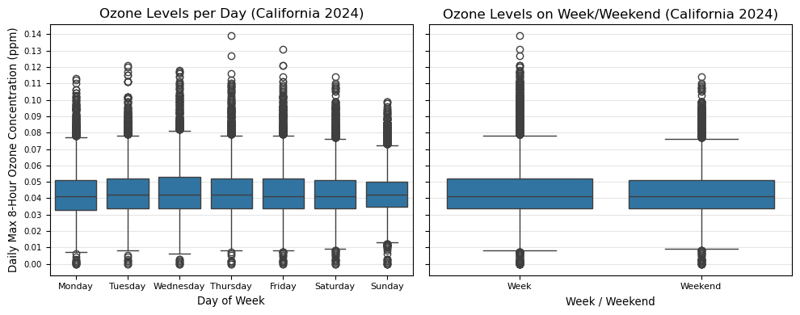

```python
#Get an initial understanding of ozone values per DoW & week/weekend
fig, axes = plt.subplots(ncols=2, figsize=(10,4), sharey=True)

#DoW
ax1 = sns.boxplot(data=data_IV, x='DoW', y='Daily Max 8-hour Ozone Concentration', ax=axes[0])
#Week/Weekend
ax1 = sns.boxplot(data=data_IV, x='Week/Weekend', y='Daily Max 8-hour Ozone Concentration', ax=axes[1])

#edit plot details
for k, v in {'Ozone Levels per Day (California 2024)':[0,'Day of Week'],
             'Ozone Levels on Week/Weekend (California 2024)':[1,'Week / Weekend']}.items():
    plt.sca(axes[v[0]])
    plt.title(k, fontsize=12)
    plt.xlabel(v[1], fontsize=9.5)
    plt.xticks(fontsize=8)
    plt.ylabel('Daily Max 8-Hour Ozone Concentration (ppm)', fontsize=9.5)
    plt.yticks(ticks=np.arange(0,0.15,0.01), fontsize=7.25)
    plt.grid(axis='y',alpha=0.2,color='gray')
    plt.tight_layout();
```

Generally, there are no major discernible differences between these figures. Some distributions on certain days are wider than others but only slightly. The one notable disparity between categories in these plots is that the most extreme ozone values observed on the weekend were slightly smaller than those during the week.

Otherwise, by using these figures alone, there is no concrete evidence that would suggest that ozone levels meaningfully differed by day or between weekdays & weekends.  
As such, a more powerful statistical method that could discern if any differences do exist may be necessary.

Hypothesis testing is a statistical procedure that takes a sample of a population dataset & evaluates the likelihood that the observed results (in the sample data) occurred due to chance under the assumption that a null hypothesis is true--that there is no difference/relationship between the groups/variables. If the probability that such observations occurred due to chance is sufficiently small, which can be quantified with the p-value, then the null hypothesis can be rejected in favor of the alternative hypothesis--that there is a difference/relationship. The p-value describes the likelihood of observing data (in the population dataset) at least as extreme as what was seen in the sample assuming that the null hypothesis is true. In other words, it quantifies the probability of extreme results occurring due to chance.

- Generally, if the calculated p-value is less than 0.05, than the null hypothesis can be rejected in favor of the alternative. In this case, the p-value describes the probability of observing a difference in ozone levels (in the population dataset) that's at least as extreme as what was observed in the sample data assuming that the null hypothesis is true--that there is not a meaningful difference in ozone levels across weekdays & weekends.
- While hypothesis testing doesn't prove or disprove anything, it is useful when quantifying if there is sufficient evidence to claim that a difference, as stated by an alternative hypothesis, exists.

There are several steps involved in such a process that can dictate what type of hypothesis test is most appropriate. Moreover, there are several aspects of the data that determine this such as the independence of data points, the sample size, how many groups are being compared, the type of data being evaluated, & more. To answer some of these questions, it is also useful to evaluate the distribution of ozone measurements across the two groups (weekdays versus weekends).

Firstly, it is important to establish that the data points being tested are independent. Recall that this section is interested in the differences of ozone levels on a statewide level during the week & on the weekends. Provided the background of this project, it is assumed that data points were measured individually & via the same process regardless of the day or the collection method. There is no indication or reason that indicates that the recording of one measurement was dependent or related to that of another. Given this, it can be assumed that the ozone levels observed during weekdays & those observed during weekends are independent.

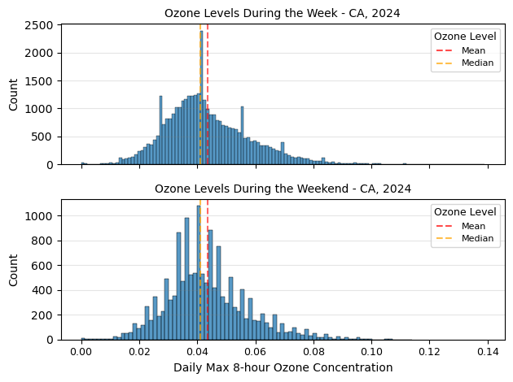

```python
#Examine the distribution of ozone levels between Week/Weekends. Add the median, mode ozone level.

fig, axes = plt.subplots(nrows=2, sharex=True)
#WEEK
ax1 = sns.histplot(data=data_IV[data_IV['Week/Weekend'] == 'Week'], x='Daily Max 8-hour Ozone Concentration', ax=axes[0])
#mean
ax1.axvline(x=data_IV[data_IV['Week/Weekend'] == 'Week']['Daily Max 8-hour Ozone Concentration'].mean(), color='red',
            alpha=0.6, linestyle='--')
#median
ax1.axvline(x=data_IV[data_IV['Week/Weekend'] == 'Week']['Daily Max 8-hour Ozone Concentration'].median(), color='orange',
            alpha=0.7, linestyle='--')

#WEEKEND
ax2 = sns.histplot(data=data_IV[data_IV['Week/Weekend'] == 'Weekend'], x='Daily Max 8-hour Ozone Concentration', ax=axes[1])
#mean
ax2.axvline(x=data_IV[data_IV['Week/Weekend'] == 'Week']['Daily Max 8-hour Ozone Concentration'].mean(), color='red',
            alpha=0.6, linestyle='--')
#median
ax2.axvline(x=data_IV[data_IV['Week/Weekend'] == 'Weekend']['Daily Max 8-hour Ozone Concentration'].median(), color='orange',
            alpha=0.7, linestyle='--')

#edit plot details
for k, v in {'Ozone Levels During the Week - CA, 2024':[0],
            'Ozone Levels During the Weekend - CA, 2024':[1]}.items():
    plt.sca(axes[v[0]])
    plt.title(k, fontsize=10)
    plt.xticks(fontsize=9, ticks=np.arange(0,0.15,0.02))
    #add a legend
    red_line = mlines.Line2D([], [], color='red', linestyle='--', alpha=0.7, label='Mean')
    orange_line = mlines.Line2D([], [], color='orange', linestyle='--', alpha=0.7, label='Median')
    plt.legend(handles=[red_line, orange_line], fontsize=8, title='Ozone Level', title_fontsize=9)
    plt.grid(axis='y',alpha=0.2,color='gray')
    plt.tight_layout();
```

Both distributions are quite similar. For both groups, their ozone levels appear to be slightly right skewed; however, there is a clear single peak in both distributions. Moreover, the average ozone levels in the two groups were higher than their respective median ozone levels. Generally, these two metrics across the two groups are very similar--slightly above 0.04 ppm.

For the purposes of hypothesis testing, these histograms indicate that the ozone levels across the two groups--weekdays & weekends--follow a clear distribution. While it is not a perfectly normal distribution, they are skewed very slightly. In other words, the difference between their mean & median ozone levels are very small.  
Moreover, both groups have a significant number of data points so sample size won't be problematic. The Central Limit Theorem states that for a significantly large sample--typically more than 30 data points--the sample means begin to approximate a normal distribution. There are over 14,000 & 36,000 data points measured in the weekend & weekday groups respectively which is more than sufficient for the Central Limit Theorem to apply. Given this & the relatively small difference between mean & median ozone levels for each of the two groups, it is reasonable to assert that these data points can be modeled by an approximately normal distribution at the very least.

> As such, parametric hypothesis tests are appropriate because, while they typically assume normally distributed group means, they can tolerate a slight skew for significantly large sample sizes. Non-parametric tests can still apply, but when the data model a clear distribution like in this case, parametric tests are more powerful.

With this established, other aspects of the dataset need to be clarified. Recall that this section seeks to determine if there is an effect on ozone levels (a continuous variable) based on whether they were measured during the week or on the weekend (two groups). As such, a two-tailed test is appropriate because the test is evaluating a general difference between the two group means. Earlier, it was clarified that the ozone levels between the two groups are independent which reinforces the Central Limit Theorem & makes a parametric t-test applicable.

> As such, a parametric, two-tailed t-test can be used to evaluate whether the average ozone levels observed on weekdays & on weekends, which are independent, are meaningfully different or not. Such a test evaluates whether there is a difference in means between the two groups.

The `scipy.stats.ttest_ind()` function was used for these purposes.

For clarity, the null (_$H_0$*) & alternative (*$H_A$_) hypotheses are listed below.

- _$H_0$_: There is no difference in the ozone levels between weekdays & weekends.
- _$H_A$_: There is a meaningful difference in the ozone levels between weekdays & weekends.
- Additionally, a significance level, *$α$*, of five percent will be set. If the p-value is less than this threshold, then the null hypothesis can be rejected in favor of the alternative hypothesis.

```python
#Retrieve ozone values for each group
data_IV_wk_oz = data_IV[data_IV['Week/Weekend'] == 'Week']['Daily Max 8-hour Ozone Concentration'].values
data_IV_wknd_oz = data_IV[data_IV['Week/Weekend'] == 'Weekend']['Daily Max 8-hour Ozone Concentration'].values
#check # observations
display(len(data_IV_wk_oz), len(data_IV_wknd_oz))
```

```
36554
```

```
14755
```

```python
#Conduct hypothesis test
display(stats.ttest_ind(data_IV_wk_oz, data_IV_wknd_oz, alternative='two-sided'))

#Calculate the difference in average ozone levels on weekdays vs weekends
wk_wknd_avg_oz_diff = data_IV[data_IV['Week/Weekend'] == 'Week']['Daily Max 8-hour Ozone Concentration'].mean() - data_IV[
                        data_IV['Week/Weekend'] == 'Weekend']['Daily Max 8-hour Ozone Concentration'].mean()
display("Difference in mean ozone levels during the week & on the weekends in California, 2024: {} ppm.".format(
            np.round(wk_wknd_avg_oz_diff, 5)))
```

```
TtestResult(statistic=3.0084405890982295, pvalue=0.002627194775871245, df=51307.0)
```

```
'Difference in mean ozone levels during the week & on the weekends in California, 2024: 0.00043 ppm.'
```

These results indicate that the probability of observing such a difference in ozone levels (or greater) in the main dataset is about 0.26% assuming that there there is no difference in average ozone levels between weekdays & weekends. In other words, if ozone levels were equivalent on weekdays & weekends in California in 2024, this test indicates that there is a 0.26% likelihood of observing a difference of 0.00043 ppm or more between the groups.  
Since the p-value is less than the established significance level of 0.05, the null hypothesis can be rejected. In other words, there is sufficient evidence to suggest that there was a meaningful difference in average ozone levels between weekdays & weekends in California in 2024.

- With this being said, the difference in average ozone levels between the two groups, shown above, is still very small; ~ 0.00043 ppm. Specifically, the average ozone levels observed during the week were about 0.00043 ppm higher than on the weekends.

These conclusions are similar to those observed in the original project (*Cleaning Data & the Skies I*), except that in the original version, there was not enough evidence to credibly assert that there was a meaningful difference in ozone levels between the two groups across the state in 2024.  
The original project also examined this data for the Los Angeles county in particular. As such, it was examined again here.

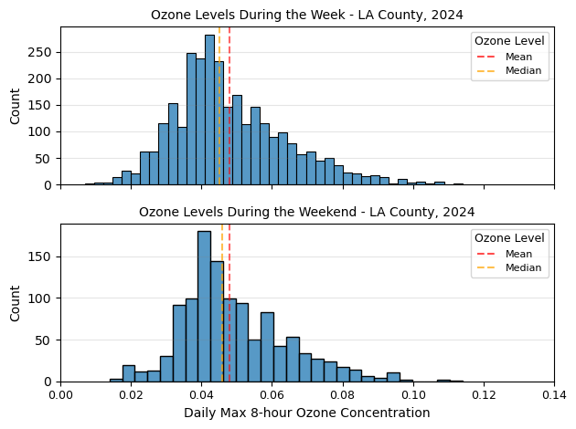

```python
#Filter for Los Angeles county
data_IV_LA = data_IV[data_IV.County == 'Los Angeles']

#Examine the distribution of ozone levels between Week/Weekends in Los Angeles county. Add the median, mode ozone level.
fig, axes = plt.subplots(nrows=2, sharex=True)
#WEEK
ax1 = sns.histplot(data=data_IV_LA[data_IV_LA['Week/Weekend'] == 'Week'], x='Daily Max 8-hour Ozone Concentration', ax=axes[0])
#mean
ax1.axvline(x=data_IV_LA[data_IV_LA['Week/Weekend'] == 'Week']['Daily Max 8-hour Ozone Concentration'].mean(), color='red',
            alpha=0.6, linestyle='--')
#median
ax1.axvline(x=data_IV_LA[data_IV_LA['Week/Weekend'] == 'Week']['Daily Max 8-hour Ozone Concentration'].median(),
            color='orange', alpha=0.7, linestyle='--')

#WEEKEND
ax2 = sns.histplot(data=data_IV_LA[data_IV_LA['Week/Weekend'] == 'Weekend'], x='Daily Max 8-hour Ozone Concentration',
                   ax=axes[1])
#mean
ax2.axvline(x=data_IV_LA[data_IV_LA['Week/Weekend'] == 'Week']['Daily Max 8-hour Ozone Concentration'].mean(), color='red',
            alpha=0.6, linestyle='--')
#median
ax2.axvline(x=data_IV_LA[data_IV_LA['Week/Weekend'] == 'Weekend']['Daily Max 8-hour Ozone Concentration'].median(),
            color='orange', alpha=0.7, linestyle='--')

#edit plot details
for k, v in {'Ozone Levels During the Week - LA County, 2024':[0],
            'Ozone Levels During the Weekend - LA County, 2024':[1]}.items():
    plt.sca(axes[v[0]])
    plt.title(k, fontsize=10)
    plt.xticks(fontsize=9, ticks=np.arange(0,0.15,0.02))
    #add a legend
    red_line = mlines.Line2D([], [], color='red', linestyle='--', alpha=0.7, label='Mean')
    orange_line = mlines.Line2D([], [], color='orange', linestyle='--', alpha=0.7, label='Median')
    plt.legend(handles=[red_line, orange_line], fontsize=8, title='Ozone Level', title_fontsize=9)
    plt.grid(axis='y',alpha=0.2,color='gray')
    plt.tight_layout();
```

While there are far less data points in the Los Angeles county, the same assumptions can still be applied as with the entire state of California beforehand. Specifically, there are still more than 1,150 data points in the two week/weekend groups for ozone readings in Los Angeles county.

```python
#Retrieve ozone values for each group
data_IV_LA_wk_oz = data_IV_LA[data_IV_LA['Week/Weekend'] == 'Week']['Daily Max 8-hour Ozone Concentration'].values
data_IV_LA_wknd_oz = data_IV_LA[data_IV_LA['Week/Weekend'] == 'Weekend']['Daily Max 8-hour Ozone Concentration'].values
#check # observations
display(len(data_IV_LA_wk_oz), len(data_IV_LA_wknd_oz))
```

```
2900
```

```
1155
```

```python
#Conduct hypothesis test
display(stats.ttest_ind(data_IV_LA_wk_oz, data_IV_LA_wknd_oz, alternative='two-sided'))

#Calculate the difference in average ozone levels on weekdays vs weekends
wk_wknd_avg_oz_diff_LA = data_IV_LA[data_IV_LA['Week/Weekend'] == 'Week'][
                                'Daily Max 8-hour Ozone Concentration'].mean() - data_IV_LA[
                            data_IV_LA['Week/Weekend'] == 'Weekend']['Daily Max 8-hour Ozone Concentration'].mean()
display("Difference in mean ozone levels during the week & on the weekends in Los Angeles, CA, 2024: {} ppm.".format(
            np.round(wk_wknd_avg_oz_diff_LA, 5)))
```

```
TtestResult(statistic=-2.04784405202947, pvalue=0.04063959482956378, df=4053.0)
```

```
'Difference in mean ozone levels during the week & on the weekends in Los Angeles, CA, 2024: -0.00113 ppm.'
```

These results indicate that the probability of observing such a difference in ozone levels (or greater) in the main dataset is about 4.06% assuming that there there is no difference in ozone levels between weekdays & weekends. In other words, if ozone levels were equivalent on weekdays & weekends in Los Angeles, CA in 2024, this test indicates that there is a 4.06% likelihood of observing a difference of 0.00113 ppm or more between the groups.  
Since the p-value is less than the established significance level of 0.05, the null hypothesis can be rejected. In other words, there is sufficient evidence to suggest that there was a meaningful difference in average ozone levels between weekdays & weekends in Los Angeles, CA in 2024.

- With this being said, the difference in average ozone levels between the two groups, shown above, is still very small; ~ 0.00113 ppm. Specifically, the average ozone levels observed during the weekend were about 0.00113 ppm higher than during the week.

These conclusions are similar to those observed in the original project (*Cleaning Data & the Skies I*), except that in the original version, there was not enough evidence to credibly assert that there was such a difference in ozone levels between the two groups in the Los Angeles county in 2024.

## Analysis IV - Conclusions

The final section of this project sought to assess whether weekends or weekdays had a significant effect on ozone levels observed throughout California in 2024.

First, average ozone levels during weekdays & on weekends in California in 2024 were analyzed to determine if there was a meaningful difference between them. A parametric, two-tailed t-test was used which resulted in the null hypothesis being rejected. More specifically, it was determined that there is sufficient evidence to suggest that there was a meaningful difference in average ozone levels between weekdays & weekends in California in 2024.

- Nonetheless, the difference in average ozone levels between the two groups is still very small (~ 0.00043 ppm). Specifically, the average ozone levels observed during the week were about 0.00043 ppm higher than on the weekends. The resulting p-value of about 0.26% indicates that this difference is statistically significant.

Next, the analysis was expanded upon by performing the same assessment for Los Angeles county in isolation. Once more, a parametric, two-tailed t-test was used to assess the average ozone levels for this specific county. It too resulted in the rejection of the null hypothesis. More specifically, it was determined that there is sufficient evidence to suggest that there was a meaningful difference in average ozone levels between weekdays & weekends in the county of Los Angeles in 2024.